# Lab 4: The Multi-Layer Perceptron

## Modeling

```python
X_train = X_train_scl_one_hot
X_test = X_test_scl_one_hot
```

```python
import numpy as np
from scipy.special import expit
import pandas as pd
import sys


class MultiLayerPerceptron(object):
    def __init__(self, n_hidden=30, n_layers=2,
                 C=0.0, epochs=500, eta=0.001, random_state=None,
                 alpha=0.0, decrease_const=0.0, shuffle=True,
                 minibatches=1):
        np.random.seed(random_state)
        self.n_layers = n_layers
        self.n_hidden = n_hidden
        self.l2_C = C
        self.epochs = epochs
        self.eta = eta
        # Mini Batch params:
        self.alpha = alpha
        self.decrease_const = decrease_const
        self.shuffle = shuffle
        self.minibatches = minibatches


    @staticmethod
    def _encode_labels(y):
        """Encode labels into one-hot representation"""
        onehot = pd.get_dummies(y).values.T

        return onehot

    def _initialize_weights(self):
        """Initialize weights Glorot and He normalization."""
        self.weights_ = []
        self.biases_ = []

        init_bound = 4*np.sqrt(6. / (self.n_hidden + self.n_features_))
        W_first = np.random.uniform(-init_bound, init_bound,(self.n_hidden, self.n_features_))
        self.weights_.append(W_first)
        b1 = np.zeros((self.n_hidden, 1))
        self.biases_.append(b1)

        # All the layers inbetween the first and last being initialized
        for i in range(1, self.n_layers-1):
            init_bound = 4*np.sqrt(6. / (self.n_hidden + self.n_hidden))
            W = np.random.uniform(-init_bound, init_bound,(self.n_hidden, self.n_hidden))
            self.weights_.append(W)
            b = np.zeros((self.n_hidden, 1))
            self.biases_.append(b)


        init_bound = 4*np.sqrt(6 / (self.n_output_ + self.n_hidden))
        W_last = np.random.uniform(-init_bound, init_bound,(self.n_output_, self.n_hidden))
        self.weights_.append(W_last)

        b2 = np.zeros((self.n_output_, 1))
        self.biases_.append(b2)

    @staticmethod
    def _sigmoid(z):
        """Use scipy.special.expit to avoid overflow"""
        return expit(z)


    def _L2_reg(self, lambda_):
        """Compute L2-regularization cost"""
        l2_reg = (lambda_/2.0)
        under_the_root = 0
        for w in self.weights_:
            under_the_root += np.mean(w ** 2)

        l2_reg *= np.sqrt(under_the_root)

        return l2_reg

    def _cost(self, A_last, Y_enc):
        '''Get the objective function value'''

        cost = -np.mean(np.nan_to_num((Y_enc*np.log(A_last)+(1-Y_enc)*np.log(1-A_last))))
        L2_term = self._L2_reg(self.l2_C)
        return cost + L2_term

    def _feedforward(self, X):
        """Compute feedforward step
        -----------
        X : Input layer with original features.
        W1: Weight matrix for input layer -> hidden layer.
        W2: Weight matrix for hidden layer -> output layer.
        ----------
        a1-a3 : activations into layer (or output layer)
        z1-z2 : layer inputs

        """
        A = []
        Z = []

        a = X.T

        for W in self.weights_:
            A.append(a)
            z = W @ a
            Z.append(z)
            a = self._sigmoid(z)
        A.append(a)
        return A, Z



    def _get_gradient(self, A, Y_enc):
        """ Compute gradient step using backpropagation.
        """

        w_gradients = []
        b_gradients = []

        v = (A[-1] - Y_enc)

        final = True
        for i in range(len(self.weights_)-1, -1, -1):

            curr_grad = v @ A[i].T
            curr_grad += self.weights_[i] * self.l2_C

            curr_bias = np.sum(v, axis=1).reshape((-1,1))

            b_gradients.append(curr_bias)
            w_gradients.append(curr_grad)

            v = A[i] * (1-A[i]) * (self.weights_[i].T @ v)

        w_gradients.reverse()
        b_gradients.reverse()

        return w_gradients, b_gradients

    def predict(self, X):
        """Predict class labels"""
        A, Z = self._feedforward(X)
        y_pred = np.argmax(A[-1], axis=0)
        return y_pred

    def fit(self, X, y, print_progress=False, XY_test=None):
        """ Learn weights from training data. With mini-batch"""
        X_data, y_data = X.copy(), y.copy()
        Y_enc = self._encode_labels(y)

        self.n_features_ = X_data.shape[1]
        self.n_output_ = Y_enc.shape[0]
        self._initialize_weights()

        self.w_grad_ = [np.zeros(self.epochs, dtype=np.float64) for i in range(self.n_layers)]
        rho_W_prev = []
        for w in self.weights_:
            rho_W_prev.append(np.zeros(w.shape))

        self.cost_ = []
        self.score_ = []
        self.score_.append(accuracy_score(y_data,self.predict(X_data)))
        if XY_test is not None:
            X_test = XY_test[0].copy()
            y_test = XY_test[1].copy()
            self.val_score_ = []
            self.val_score_.append(accuracy_score(y_test,self.predict(X_test)))

        for i in range(self.epochs):
            eta = self.eta / (1 + self.decrease_const*i)

            if print_progress>0 and (i+1)%print_progress==0:
                sys.stderr.write('\rEpoch: %d/%d' % (i+1, self.epochs))
                sys.stderr.flush()

            if self.shuffle:
                idx_shuffle = np.random.permutation(y_data.shape[0])
                X_data, Y_enc, y_data = X_data[idx_shuffle], Y_enc[:, idx_shuffle], y_data[idx_shuffle]

            mini = np.array_split(range(y_data.shape[0]), self.minibatches)
            mini_cost = []
            for idx in mini:

                A, Z = self._feedforward(X_data[idx])

                cost = self._cost(A[-1], Y_enc[:, idx])

                mini_cost.append(cost)
                w_gradients, b_gradients = self._get_gradient(A, Y_enc=Y_enc[:, idx])

                for j in range(len(w_gradients)):
                    self.w_grad_[j][i] = np.linalg.norm(w_gradients[j])

                rho = [gradient*eta for gradient in w_gradients]

                for w in range(len(self.weights_)):
                    self.weights_[w] -= (rho[w] + (self.alpha * rho_W_prev[w]))
                    self.biases_[w] -= eta * b_gradients[w]
                rho_W_prev = rho


            self.cost_.append(mini_cost)
            self.score_.append(accuracy_score(y_data,self.predict(X_data)))
            if XY_test is not None:
                self.val_score_.append(accuracy_score(y_test,self.predict(X_test)))

        return self
```

## Third Layer Model

```python
hyper_params["epochs"] = 60
hyper_params["n_layers"] = 3
model4 = MultiLayerPerceptron(**hyper_params)
model4.fit(X_train, y_train, print_progress=1, XY_test=(X_test,y_test))
```

```
Epoch: 60/60
```

```
<__main__.MultiLayerPerceptron at 0x16a690e10>
```

```
Accuracy: 73.67%
```

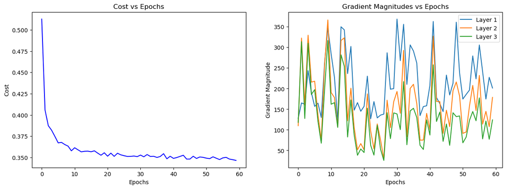

```python
y_pred = model4.predict(X_test)
print('Accuracy: %.2f%%' % (accuracy_score(y_test, y_pred)*100))
fig, (ax1, ax2) = plt.subplots(1, 2, figsize=(15,5))
cost_avgs = np.mean(model4.cost_,axis=1)
ax1.plot(range(len(cost_avgs)), cost_avgs, color='blue')
ax1.set_ylabel('Cost')
ax1.set_xlabel('Epochs')
ax1.set_title('Cost vs Epochs')
for i in range(len(model4.w_grad_)):
    ax2.plot(range(len(model4.w_grad_[i])), model4.w_grad_[i], label="Layer {}".format(i+1))
ax2.set_ylabel('Gradient Magnitude')
ax2.set_xlabel('Epochs')
ax2.set_title('Gradient Magnitudes vs Epochs')
ax2.legend()
plt.show()
```

## Fourth Layer Model

```python
hyper_params["n_layers"] = 4
model5 = MultiLayerPerceptron(**hyper_params)
model5.fit(X_train, y_train, print_progress=1, XY_test=(X_test,y_test))
```

```
Epoch: 60/60
```

```
<__main__.MultiLayerPerceptron at 0x16a935b10>
```

```
Accuracy: 73.52%
```

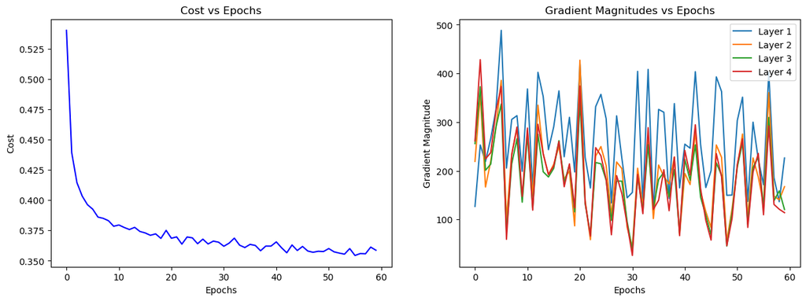

```python
y_pred = model5.predict(X_test)
print('Accuracy: %.2f%%' % (accuracy_score(y_test, y_pred)*100))
fig, (ax1, ax2) = plt.subplots(1, 2, figsize=(15,5))
cost_avgs = np.mean(model5.cost_,axis=1)
ax1.plot(range(len(cost_avgs)), cost_avgs, color='blue')
ax1.set_ylabel('Cost')
ax1.set_xlabel('Epochs')
ax1.set_title('Cost vs Epochs')
for i in range(len(model5.w_grad_)):
    ax2.plot(range(len(model5.w_grad_[i])), model5.w_grad_[i], label="Layer {}".format(i+1))
ax2.set_ylabel('Gradient Magnitude')
ax2.set_xlabel('Epochs')
ax2.set_title('Gradient Magnitudes vs Epochs')
ax2.legend()
plt.show()
```

## Fifth Layer Model

```python
hyper_params["n_layers"] = 5
model6 = MultiLayerPerceptron(**hyper_params)
model6.fit(X_train, y_train, print_progress=1, XY_test=(X_test,y_test))
```

```
Epoch: 60/60
```

```
<__main__.MultiLayerPerceptron at 0x16a9bded0>
```

```
Accuracy: 73.11%
```

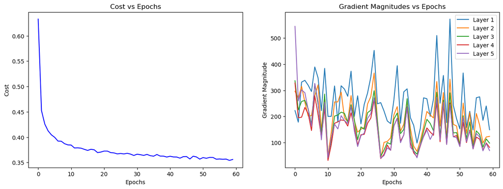

```python
y_pred = model6.predict(X_test)
print('Accuracy: %.2f%%' % (accuracy_score(y_test, y_pred)*100))
fig, (ax1, ax2) = plt.subplots(1, 2, figsize=(15,5))
cost_avgs = np.mean(model6.cost_,axis=1)
ax1.plot(range(len(cost_avgs)), cost_avgs, color='blue')
ax1.set_ylabel('Cost')
ax1.set_xlabel('Epochs')
ax1.set_title('Cost vs Epochs')
for i in range(len(model6.w_grad_)):
    ax2.plot(range(len(model6.w_grad_[i])), model6.w_grad_[i], label="Layer {}".format(i+1))
ax2.set_ylabel('Gradient Magnitude')
ax2.set_xlabel('Epochs')
ax2.set_title('Gradient Magnitudes vs Epochs')
ax2.legend()
plt.show()
```

## Adaptive Learning Technique Model (AdaDelta)

```python
class AdaDeltaMLP(MultiLayerPerceptron):
    def __init__(self, B1=.9, B2=.999, epsilon = 10e-8, **kwargs):
        super().__init__(**kwargs)
        self.epsilon = epsilon
        self.B1 = B1
        self.B2 = B2

    def fit(self, X, y, print_progress=False, XY_test=None):
        """ Learn weights from training data. With mini-batch"""
        X_data, y_data = X.copy(), y.copy()
        Y_enc = self._encode_labels(y)

        self.n_features_ = X_data.shape[1]
        self.n_output_ = Y_enc.shape[0]
        self._initialize_weights()

        self.w_grad_ = [np.zeros(self.epochs, dtype=np.float64) for i in range(self.n_layers)]
        Vk_prev = []
        Mk_prev = []

        for w in self.weights_:
            Vk_prev.append(np.zeros(w.shape))
            Mk_prev.append(np.zeros(w.shape))

        Vk = Vk_prev
        Mk = Mk_prev

        self.cost_ = []
        self.score_ = []
        self.score_.append(accuracy_score(y_data,self.predict(X_data)))
        if XY_test is not None:
            X_test = XY_test[0].copy()
            y_test = XY_test[1].copy()
            self.val_score_ = []
            self.val_score_.append(accuracy_score(y_test,self.predict(X_test)))

        for i in range(self.epochs):

            if print_progress>0 and (i+1)%print_progress==0:
                sys.stderr.write('\rEpoch: %d/%d' % (i+1, self.epochs))
                sys.stderr.flush()

            if self.shuffle:
                idx_shuffle = np.random.permutation(y_data.shape[0])
                X_data, Y_enc, y_data = X_data[idx_shuffle], Y_enc[:, idx_shuffle], y_data[idx_shuffle]

            mini = np.array_split(range(y_data.shape[0]), self.minibatches)
            mini_cost = []
            for idx in mini:

                A, Z = self._feedforward(X_data[idx])

                cost = self._cost(A[-1], Y_enc[:, idx])

                mini_cost.append(cost)
                w_gradients, b_gradients = self._get_gradient(A, Y_enc=Y_enc[:, idx])

                for j in range(len(w_gradients)):
                    self.w_grad_[j][i] = np.linalg.norm(w_gradients[j])

                Gk = [gradient**2 for gradient in w_gradients]

                for j,square_grad in enumerate(Gk):
                    Vk[j] = self.B2 * Vk_prev[j] + (1-self.B2) * square_grad
                for j in range(len(w_gradients)):
                    Mk[j] = self.B1 * Mk_prev[j] + (1-self.B1) * w_gradients[j]

                for w in range(len(self.weights_)):
                    self.weights_[w] -= self.eta * (Mk[w] / (np.sqrt(Vk[w] + self.epsilon)))
                    self.biases_[w] -= self.eta * b_gradients[w]
                Vk_prev = Vk
                Mk_prev = Mk

            self.cost_.append(mini_cost)
            self.score_.append(accuracy_score(y_data,self.predict(X_data)))
            if XY_test is not None:
                self.val_score_.append(accuracy_score(y_test,self.predict(X_test)))

        return self
```

```python
hyper_params['epochs'] = 60
hyper_params["n_layers"] = 5
hyper_params["B1"] = .8
hyper_params["B2"] = .8
model7 = AdaDeltaMLP(**hyper_params)
model7.fit(X_train, y_train, print_progress=1, XY_test=(X_test,y_test))
```

```
Epoch: 60/60
```

```
<__main__.AdaDeltaMLP at 0x16ab3c450>
```

```
Accuracy: 73.65%
```

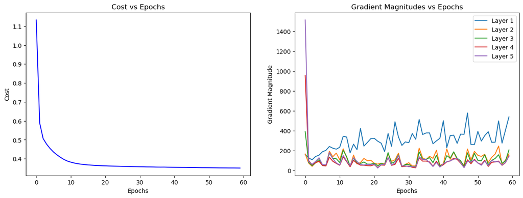

```python
y_pred = model7.predict(X_test)
print('Accuracy: %.2f%%' % (accuracy_score(y_test, y_pred)*100))
fig, (ax1, ax2) = plt.subplots(1, 2, figsize=(15,5))
cost_avgs = np.mean(model7.cost_,axis=1)
ax1.plot(range(len(cost_avgs)), cost_avgs, color='blue')
ax1.set_ylabel('Cost')
ax1.set_xlabel('Epochs')
ax1.set_title('Cost vs Epochs')
for i in range(len(model7.w_grad_)):
    ax2.plot(range(len(model7.w_grad_[i])), model7.w_grad_[i], label="Layer {}".format(i+1))
ax2.set_ylabel('Gradient Magnitude')
ax2.set_xlabel('Epochs')
ax2.set_title('Gradient Magnitudes vs Epochs')
ax2.legend()
plt.show()
```

Exponential moving averages are particularly beneficial in addressing the challenges associated with sparse data, a common occurrence in adaptive learning rate methods like Nesterov's Momentum and Momentum. Rather than relying on a single average gradient, AdaDelta and AdaGrad calculate average gradients for each individual element within the weight matrix. This adaptive approach allows the algorithm to adjust to the data's sparsity, facilitating faster convergence. AdaDelta further resolves the problem of monotonically decreasing learning rates by introducing an exponentially decaying average of squared gradients. This dynamic update mechanism adapts to high-gradient areas and expedites progress on plateaus.

## Adaptive Momemtum Model (AdaM)

```python
class AdaMMLP(AdaDeltaMLP):
    def __init__(self,  **kwds):
        super().__init__(**kwds)

    def fit(self, X, y, print_progress=False, XY_test=None):
        """ Learn weights from training data. With mini-batch"""
        X_data, y_data = X.copy(), y.copy()
        Y_enc = self._encode_labels(y)

        self.n_features_ = X_data.shape[1]
        self.n_output_ = Y_enc.shape[0]
        self._initialize_weights()

        self.w_grad_ = [np.zeros(self.epochs, dtype=np.float64) for i in range(self.n_layers)]

        moment_1_prev = [np.zeros(w.shape) for w in self.weights_]
        moment_2_prev = [np.zeros(w.shape) for w in self.weights_]

        moment_1 = moment_1_prev
        moment_2 = moment_2_prev

        self.cost_ = []
        self.score_ = []
        self.score_.append(accuracy_score(y_data,self.predict(X_data)))
        if XY_test is not None:
            X_test = XY_test[0].copy()
            y_test = XY_test[1].copy()
            self.val_score_ = []
            self.val_score_.append(accuracy_score(y_test,self.predict(X_test)))

        for i in range(self.epochs):
            if print_progress>0 and (i+1)%print_progress==0:
                sys.stderr.write('\rEpoch: %d/%d' % (i+1, self.epochs))
                sys.stderr.flush()

            if self.shuffle:
                idx_shuffle = np.random.permutation(y_data.shape[0])
                X_data, Y_enc, y_data = X_data[idx_shuffle], Y_enc[:, idx_shuffle], y_data[idx_shuffle]

            mini = np.array_split(range(y_data.shape[0]), self.minibatches)
            mini_cost = []
            for idx in mini:

                A, Z = self._feedforward(X_data[idx])

                cost = self._cost(A[-1], Y_enc[:, idx])

                mini_cost.append(cost)

                w_gradients, b_gradients = self._get_gradient(A, Y_enc=Y_enc[:, idx])

                for j in range(len(w_gradients)):
                    self.w_grad_[j][i] = np.linalg.norm(w_gradients[j])

                for j,gradient in enumerate(w_gradients):
                    moment_1[j] = self.B1 * moment_1_prev[j] + (1 - self.B1) * gradient
                    moment_2[j] = self.B2 * moment_2_prev[j] + (1 - self.B2) * gradient**2

                moment_1_hat = [m/(1-self.B1**(i+1)) for m in moment_1]
                moment_2_hat = [m/(1-self.B2**(i+1)) for m in moment_2]

                for w in range(len(self.weights_)):
                    self.weights_[w] -= self.eta * (moment_1_hat[w] / (np.sqrt(moment_2_hat[w] + self.epsilon)))
                    self.biases_[w] -= self.eta * b_gradients[w]

                moment_1_prev = moment_1
                moment_2_prev = moment_2


            self.cost_.append(mini_cost)
            self.score_.append(accuracy_score(y_data,self.predict(X_data)))
            if XY_test is not None:
                self.val_score_.append(accuracy_score(y_test,self.predict(X_test)))

        return self
```

```python
hyper_params['epochs'] = 60
hyper_params["n_layers"] = 5
hyper_params["B1"] = .8
hyper_params["B2"] = .8
model8 = AdaMMLP(**hyper_params)
model8.fit(X_train, y_train, print_progress=1, XY_test=(X_test,y_test))
```

```
Epoch: 60/60
```

```
<__main__.AdaMMLP at 0x16a697a10>
```

```
Accuracy: 73.60%
```

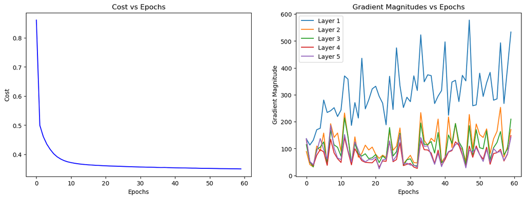

```python
y_pred = model8.predict(X_test)
print('Accuracy: %.2f%%' % (accuracy_score(y_test, y_pred)*100))
fig, (ax1, ax2) = plt.subplots(1, 2, figsize=(15,5))
cost_avgs = np.mean(model8.cost_,axis=1)
ax1.plot(range(len(cost_avgs)), cost_avgs, color='blue')
ax1.set_ylabel('Cost')
ax1.set_xlabel('Epochs')
ax1.set_title('Cost vs Epochs')
for i in range(len(model8.w_grad_)):
    ax2.plot(range(len(model8.w_grad_[i])), model8.w_grad_[i], label="Layer {}".format(i+1))
ax2.set_ylabel('Gradient Magnitude')
ax2.set_xlabel('Epochs')
ax2.set_title('Gradient Magnitudes vs Epochs')
ax2.legend()
plt.show()
```

ADAM follows a process that is very similiar to AdaDelta but it shows an increase of moments, specifically the falling momentum and squared gradient terms. This helps to counteract the inherent bias. The bias towards zero often appears after the initialization of Mk and Vk. As the value in k increases, the moment estimate continuosly approaces the actual values of Mk and Vk which results in better convergence.